# Análisis de la estabilidad de los centroides en K-Medias en presencia de correlación

Davinson Montoya Ramirez Jessica Maria Rivera Jimenez Luis Felipe Arevalo Cortes Universidad Nacional de Colombia - Sede Medellín Decisiones bajo incertidumbre (Optimización para aprendizaje de máquina)

Semestre 2021-01

### Objetivo de la Actividad

Como objetivo, la actividad plantea el uso del algoritmo kmeans para evidenciar como a medida que la correlación se hace presente dentro de las variables a agrupar, la variabilidad de los centroides aumenta.

### Metodología Realizada

La metodología implementada en la solución de la actividad fue Kmeans, esta técnica es una algoritmo de clasificación no supervisada o clustering que usa la distancia de las observaciones a un centroide definido para determinar su pertenencia al grupo dado por dicho centroide, la definición de la cantidad de grupos (definición del parámetro k) a encontrar por el algoritmo, se realiza previamente a la inicialización de kmeans, una de las técnicas para definir esta cantidad de grupos es la gráfica de codo o en ingles Elbow method. Los pasos usados por kmeans son: 1. Selección de k centroides (esta selección se realiza de manera aleatoria). 2. Asignación de las observaciones al centroide más cercano (usa distancia cuadrática). 3. Actualización de los centroides, una vez clasificado cada observación se promedian los valores de cada grupo formado y dicho promedio se convierte en el nuevo centroide.

## Distribución Normal Bivariada

La distribución normal bivariada es definida por un vector de medias y la matriz de varianzas-covarianzas. La distribución normal multivariada es una extensión de la distribución normal univariada para aplicaciones con un grupo de variables que pueden estar correlacionadas.

Inicialmente, se quieren modelar diferentes distribuciones que sean independientes y que tengan traslape entre ellas, contenidas en dos variables x1(Eje x) y x2(Eje y). Para 3 distribuciones se definen los siguientes tamaños de muestra:

```r
knitr::opts_chunk$set(echo = TRUE, cache = TRUE)

n1<-130 # Tamaño de la muestra de la clase 1
n2<-110 # Tamaño de la muestra de la clase 2
n3<-100 # Tamaño de la muestra de la clase 3
```

Los vectores de medias en cada conjunto se muestran a continuación:

```r
knitr::opts_chunk$set(echo = TRUE, cache = TRUE)
mu3<-c(0.7,2.2) # Vector de medias de la clase 1
mu4<-c(-0.2,1.7) # Vector de medias de la clase 2
mu5<-c(-1.6,1) # Vector de medias de la clase 3
```

### La correlación entre variables

La correlación de Pearson mide el grado de relación lineal entre dos variables, estos valores pueden ir entre -1 y 1, la matriz de correlación muestra estos valores.

```r
knitr::opts_chunk$set(echo = TRUE, cache = TRUE)
M_cor<-matrix(c(1,0.4,0.4,1),ncol=2)
```

### Matriz de Covarianza

la matriz de covarianza muestra esta relacion para cada par de variables. A partir de la matriz de correlación definida, se ajusta la matriz de covarianza, y además un vector para la desviación estándar de nuestra matriz. Luego, se busca la matriz positiva más cercana por medio de la función nearPD

```r
knitr::opts_chunk$set(echo = TRUE, cache = TRUE)
M_cov<-cor2cov(M_cor,sd=c(0.7,0.7))
M_cov_pd<-as.matrix(nearPD(M_cov)$mat)
```

### Definición de las Distribuciones

Con el fin de lograr la replicabilidad en los datos, se define una semilla de tamaño 100 y se generan las distribuciones utilizando la función rmvnorm, donde recoge el tamaño de muestra, la matriz de covarianza ajustada y el método “eigen” para descomponer la matriz en una forma estándar

```r
knitr::opts_chunk$set(echo = TRUE, cache = TRUE)
set.seed(100)
muestra3<-rmvnorm(n=n1,mean=mu3,sigma=M_cov_pd,method="eigen")
muestra4<-rmvnorm(n=n2,mean=mu4,sigma=M_cov_pd,method="eigen")
muestra5<-rmvnorm(n=n3,mean=mu5,sigma=M_cov_pd,method="eigen")
```

### Graficando las distribuciones simuladas

Por medio del método rbind, se unen las 3 muestras y se agrupan como un dataframe para graficar. En “clase” se definen los colores que va a tener cada conjunto para diferenciarse entre sí. En la gráfica se agrega el dataframe creado, se ajustan bordes, colores, título, cuadrícula y leyenda, donde se muestra a continuación:

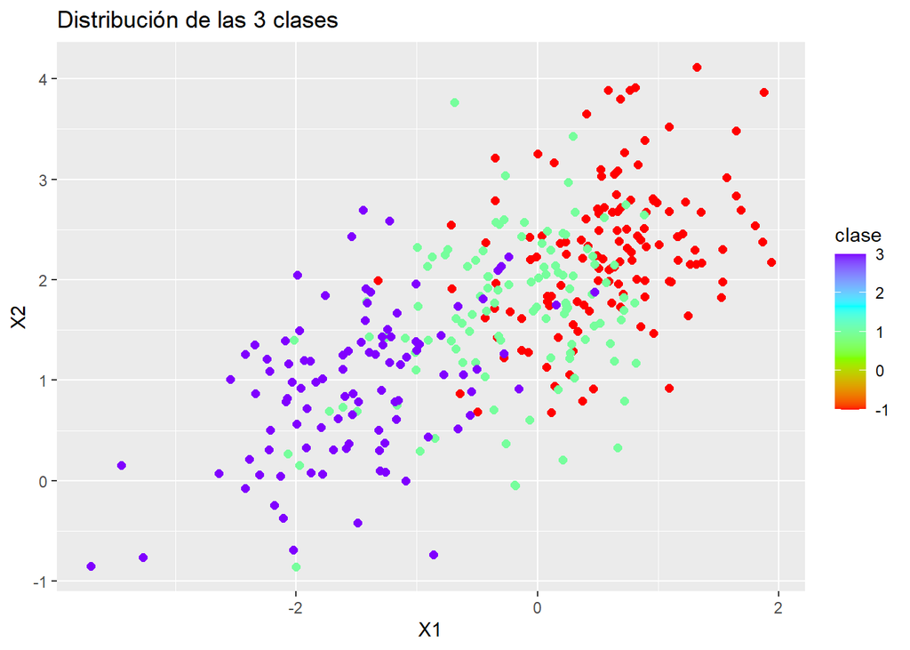

```r
knitr::opts_chunk$set(echo = TRUE, cache = TRUE)
muestra_nosep<-rbind(muestra3,muestra4,muestra5)
clase<-c(rep(-1,n1),rep(1,n2),rep(3,n3))
muestra_nosep_df<-data.frame(muestra_nosep)
ggplot() + geom_point(aes(x = X1, y = X2, color = clase), data = muestra_nosep_df, size = 2) +
  scale_colour_gradientn(colours=rainbow(4)) +
ggtitle('Distribución de las 3 clases') +
  xlab('X1') + ylab('X2')
```

## Utilizando el método k-means

Se utilizará el método de k-means para establecer en 3 grupos todo el conjunto de datos. Se definen 100 inicializaciones aleatorias para el método, y se calculan sus centroides.

```r
knitr::opts_chunk$set(echo = TRUE, cache = TRUE)
n_c=100
k1 <- kmeans(muestra_nosep_df, 3, nstart = n_c)
cent <- k1$centers
print(cent)
```

[output not shown]

## Visualización de los centroides con los conjuntos de datos agrupados

Con la información del conjunto de datos agrupado en 3 clusters, se procede a mostrar gráficamente los resultados, resaltando los centroides en cada grupo.

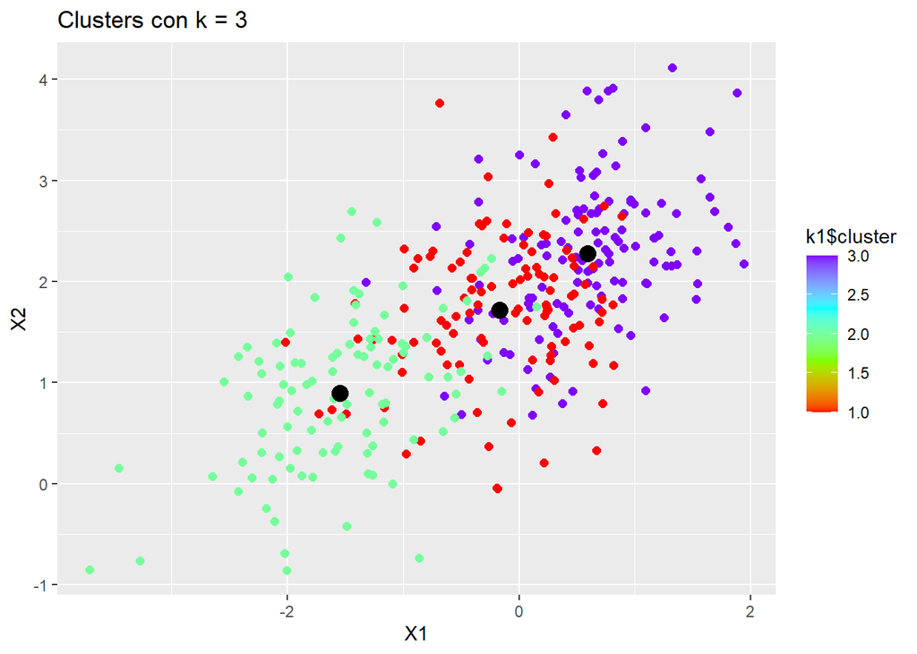

```r
knitr::opts_chunk$set(echo = TRUE, cache = TRUE)
ggplot() + geom_point(aes(x = X1, y = X2, color = k1$cluster), data = muestra_nosep_df, size = 2) + scale_colour_gradientn(colours=rainbow(4)) + geom_point(aes(x = k1$centers[,1], y = k1$centers[,2]), color = "black", size = 4) + ggtitle("Clusters con k = 3") + xlab("X1") + ylab("X2")
```

3. Suponga que el $i$-ésimo individuo es de la forma $X_i = [x_1^i \quad x_2^i]^T$. Cree la variable $x_3$ como $x_3^i=x_1^i+\epsilon_i$ con $\epsilon_i$ iid de media cero y varianza constante. ¿Cuál es la varianza de $x_3$? ¿Cuál es la covarianza entre $x_1$ y $x_3$? ¿Al agregar esta variable K-Means sigue detectando correctamente los centroides? ¿Qué pasa con la estabilidad de los centroides cuando la varianza de $\epsilon$ aumenta?

## Agregando una variable adicional correlacionada

Se crea $x_3$ como la suma de $x_1$ y $\epsilon$

```r
knitr::opts_chunk$set(echo = TRUE, cache = TRUE)
e<-rnorm(n=340,mean=0, sd = 3)
x3 <- muestra_nosep_df$X1 + e
```

Se calcula la varianza de $x_3$

```r
knitr::opts_chunk$set(echo = TRUE, cache = TRUE)
var(x3, y = NULL, na.rm = FALSE)
```

[output not shown]

Covarianza entre $x_3$ y $x_1$

```r
knitr::opts_chunk$set(echo = TRUE, cache = TRUE)
print('Covarianza entre X3 y X1')
```

```
## [1] "Covarianza entre X3 y X1"
```

```r
cov(muestra_nosep_df$X1, y = x3, use = "everything",
    method = c("pearson", "kendall", "spearman"))
```

```
## [1] 0.9921746
```

Realizando el método k-means con la nueva variable $x_3$. Se observan los centroides para cada una de las variables.

```r
muestra_p3<-cbind(muestra_nosep_df$X1,muestra_nosep_df$X2,x3)
muestra_p3_df<-data.frame(muestra_p3)
col_headings <- c('X1','X2','X3')
names(muestra_p3_df) <- col_headings
n_c=100
p3k1 <- kmeans(muestra_p3_df, 3, nstart = n_c)
cent1 <- p3k1$centers
print(cent1)
```

```
##           X1       X2         X3
## 1  0.1272930 1.817213  3.3149475
## 2 -0.8941903 1.380104 -3.9979571
## 3 -0.1593802 1.793754 -0.4370038
```

## ¿Qué pasa si aumenta la varianza?

Se añadirá mayor varianza al conjunto de $\epsilon$ y veremos como se comporta

```r
knitr::opts_chunk$set(echo = TRUE, cache = TRUE)
lista_centroides = data.frame()
for(i in 5:8){
e<-rnorm(n=340,mean=0, sd = i)
x3 <- muestra_nosep_df$X1 + e
muestra_p3<-cbind(muestra_nosep_df$X1,muestra_nosep_df$X2,x3)
muestra_p3_df<-data.frame(muestra_p3)
col_headings <- c('X1','X2','X3')
names(muestra_p3_df) <- col_headings
n_c=100
p3k1 <- kmeans(muestra_p3_df, 3, nstart = n_c)
cent1 <- p3k1$centers
clus1 <- p3k1$cluster
df <- data.frame(cent1)
lista_centroides <- rbind(lista_centroides, df)
}


print(lista_centroides)
```

```
##             X1       X2         X3
## 1  -0.02551420 1.875975  6.8780725
## 2  -0.67001370 1.475818 -5.6587400
## 3  -0.08638559 1.774826  0.8109437
## 11 -0.48372326 1.615370 -8.9154710
## 21 -0.30739478 1.627956 -0.7947451
## 31 -0.11979739 1.823179  7.4017634
## 12 -0.50020425 1.557564 -7.7327027
## 22 -0.24569113 1.688613  1.4987398
## 32  0.06336867 1.970044 11.0502449
## 13 -0.14799593 1.682492  8.3578479
## 23 -0.16801905 1.781888 -0.6954791
## 33 -0.59156079 1.555113 -9.1846273
```

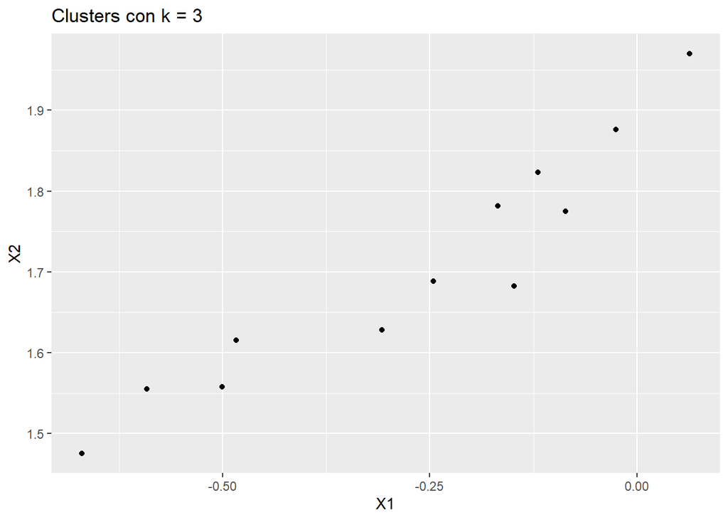

```r
ggplot(aes(x = X1, y = X2), data = lista_centroides, size = 2) + geom_point() + ggtitle("Clusters con k = 3") + xlab("X1") + ylab("X2")
```

A medida que la varianza aumenta, los centroides se van dispersando cada vez más entre sí

## Agregando 3 variables adicionales

Se definen 3 varaibles correlacionadas con las variables anteriormente declaradas

```r
knitr::opts_chunk$set(echo = TRUE, cache = TRUE)
e4<-rnorm(n=340,mean=0, sd = 3)
x4 <- muestra_p3_df$X2 + e4

e6<-rnorm(n=340,mean=0, sd = 2)
x6 <- muestra_p3_df$X2 + e6

e5<-rnorm(n=340,mean=0, sd = 4)
x5 <- muestra_p3_df$X3 + e5
```

Se realiza el k-means para este nuevo conjunto y se observa lo siguiente:

```r
knitr::opts_chunk$set(echo = TRUE, cache = TRUE)
muestra_p4<-cbind(muestra_p3_df$X1, muestra_p3_df$X2, muestra_p3_df$X3, x4, x5, x6)
muestra_p4_df<-data.frame(muestra_p4)
col_headings <- c('X1','X2','X3','X4','X5','X6')
names(muestra_p4_df) <- col_headings
n_c=100
p4k1 <- kmeans(muestra_p4_df, 3, nstart = n_c)
cent2 <- p4k1$centers
print(cent2)
```

```
##           X1       X2         X3       X4         X5       X6
## 1 -0.5823188 1.521055 -10.115062 1.444713 -11.924914 1.693595
## 2 -0.2710090 1.742046  -1.538678 1.681843  -1.603059 1.736432
## 3 -0.1073776 1.717184   7.602513 1.523019   9.542040 1.834769
```

## Que pasa si aumenta la varianza con estas 3 nuevas variables?

Como era de esperarse, al aumentar la varianza, también aumenta la inestabilidad de los centroides en cada iteración, en total se incrementó la varianza 4 veces desde una desviación estándar de 5 hasta una desviación estándar de 8.

```r
knitr::opts_chunk$set(echo = TRUE, cache = TRUE)
lista_centroides2 = data.frame()
for(i in 5:8){
e<-rnorm(n=340,mean=0, sd = i)
x3 <- muestra_nosep_df$X1 + e

e4<-rnorm(n=340,mean=0, sd = i)
x4 <- muestra_nosep_df$X2 + e4

e6<-rnorm(n=340,mean=0, sd = i)
x6 <- muestra_nosep_df$X2 + e6

e5<-rnorm(n=340,mean=0, sd = i)
x5 <- x3 + e5


muestra_p4<-cbind(muestra_nosep_df$X1, muestra_nosep_df$X2, x3, x4, x5, x6)
muestra_p4_df<-data.frame(muestra_p4)
col_headings <- c('X1','X2','X3','X4','X5','X6')
names(muestra_p4_df) <- col_headings
n_c=100
p4k1 <- kmeans(muestra_p4_df, 3, nstart = n_c)
cent2 <- p4k1$centers
clus2 <- p4k1$cluster
df2 <- data.frame(cent2)
lista_centroides2 <- rbind(lista_centroides2, df2)
}

print(lista_centroides2)
```

```
##             X1       X2           X3         X4          X5         X6
## 1  -0.01416702 1.907754  4.748895604  2.3035428   7.9833260  1.5665865
## 2  -0.66206721 1.374760 -4.494316111  0.8307787  -7.0990774 -1.1810074
## 3  -0.22262913 1.745334 -0.794349995  1.9109754  -0.5925202  4.3407628
## 11 -0.08535386 1.836879  5.143652472  2.7991812   8.6111912  2.5665858
## 21 -0.24006462 1.662975 -1.197555432  1.6159182  -1.2445546 -0.6348549
## 31 -0.56454782 1.560678 -7.157738120  0.5112154 -10.7376754  3.5852706
## 12 -0.41554448 1.595330 -8.306881640  2.9127566 -13.9641043  4.7293806
## 22 -0.04944131 1.909754  7.170695285  2.7861746  10.0309258  3.4016771
## 32 -0.42836712 1.539117 -1.737811989 -0.5679489  -1.3646290 -0.5246315
## 13 -0.12381149 1.775744  8.673424421  1.0883812  13.7249056  3.5964081
## 23 -0.35391999 1.665998 -0.001299805  2.8667729  -0.4084730 -0.1303047
## 33 -0.35217830 1.623427 -9.946893991  1.6503551 -13.4709341  3.4306362
```

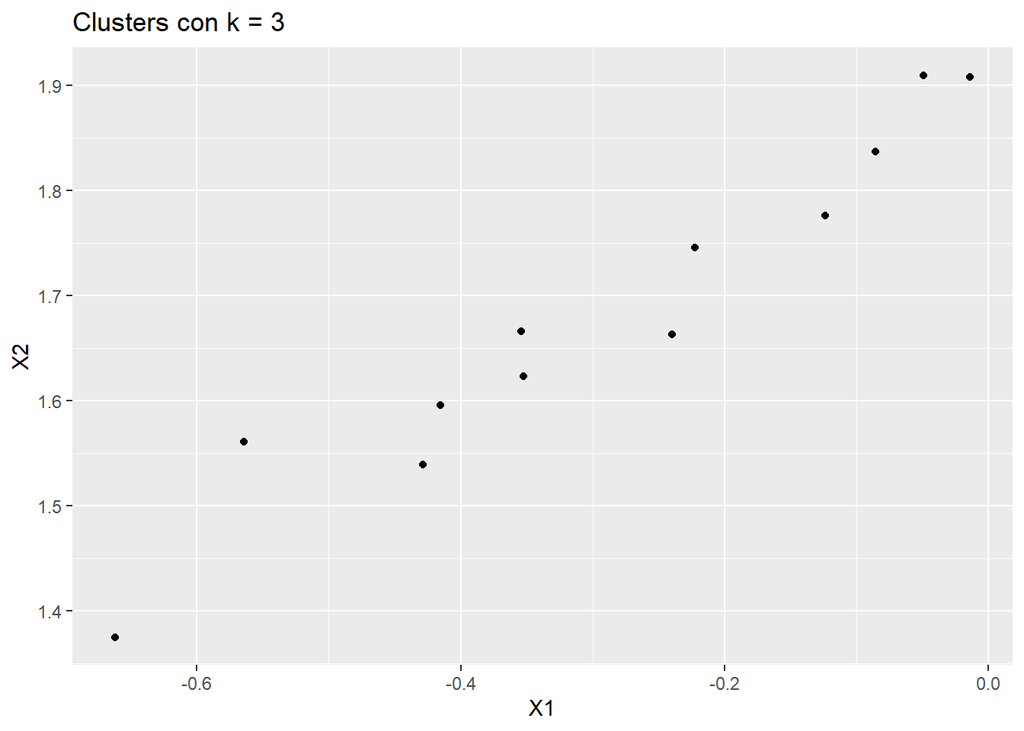

```r
ggplot(aes(x = X1, y = X2), data = lista_centroides2, size = 2) + geom_point() + ggtitle("Clusters con k = 3") + xlab("X1") + ylab("X2")
```

## Conclusiones y Análisis de los resultados

Cuando encontramos que las variables que se deben agrupar están correlacionadas y los resultados de kmeans están viéndose afectados, lo más recomendable es utilizar algún método de reducción de dimensionalidad que nos permita seleccionar las variables más adecuadas para la agrupación, el análisis de componentes principales es uno de los recomendados ya que permite simplificar la información de varias variables en pocos componentes. Además es pertinente antes de realizar un agrupamiento por kmeans realizar un análisis de la dispersión de las variables involucradas para encontrar datos atípicos que afecten también los resultados de kmeans. Se observó que los centroides se alejaban más entre sí a medida que se agregaban variables y a medida que la varianza de unas variables correlacionadas tambien aumentaba.

## ¿Qué se podría decir del efecto de la correlación entre variables y la estabilidad de los centroides en K-Medias?

Por la existencia de la correlación y covarianza entre las variables de las distribuciones, el k-means no logra diferenciar correctamente los grupos. Además, con el ingreso de las últimas variables, se evidencian valores lejanos que halan los centrodies de los clusters en dicha dirección, afectando su diferenciación.

### Bibliografía

Geeksforgeeks. (2021). Elbow Method for optimal value of k in KMeans. https://www.geeksforgeeks.org/elbow-method-for-optimal-value-of-k-in-kmeans/ MamutCola. (n.d.). Introducción a las técnicas multivariantes de clasificación. http://ares.inf.um.es/00Rteam/pub/mamutCola/modulo6.html RPUBS. (2019).Matrices, Vectores y Escalares. https://rpubs.com/cete/fundamentosr3 Sitiobigdata. (2019). Covarianza y correlación: comprendiendo su utilidad. https://sitiobigdata.com/2019/10/26/covarianza-y-correlacion/# SOLIN. (2017). MEDIA VARIANZA COVARIANZA REGRESIÓN LINEAL. http://www.solin.16mb.com/estadistica_js/VarianzaCovarianzaRegresion.htm stat.ethz. (n.d.). Correlation, Variance and Covariance (Matrices). https://stat.ethz.ch/R-manual/R-devel/library/stats/html/cor.html UNIOVIEDO. (n.d.). El algoritmo k-means aplicado a clasificación y procesamiento de imágenes. https://www.unioviedo.es/compnum/laboratorios_py/kmeans/kmeans.html Wikipedia. (n.d.). Matriz de covarianza. https://es.wikipedia.org/wiki/Matriz_de_covarianza (UNIOVIEDO, n.d.)(Geeksforgeeks, 2021) El algoritmo k-means aplicado a clasificación y procesamiento de imágenes https://www.unioviedo.es/compnum/laboratorios_py/kmeans/kmeans.html Elbow Method for optimal value of k in KMeans https://www.geeksforgeeks.org/elbow-method-for-optimal-value-of-k-in-kmeans/